# Proyecto Big Data

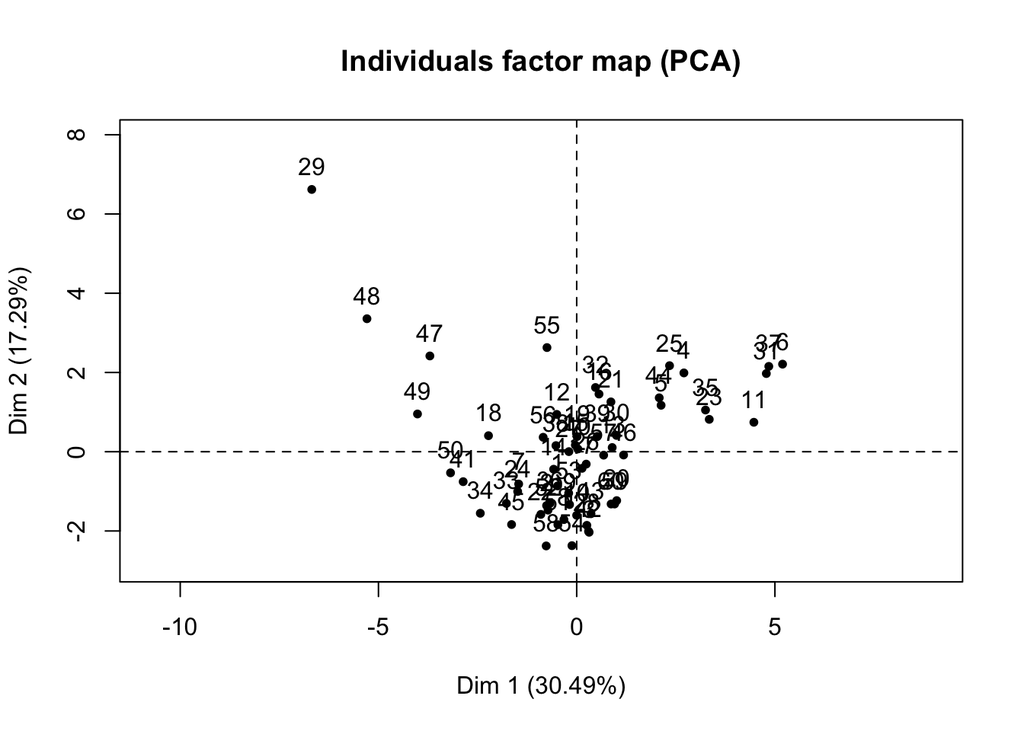

```r
plot(pca)
```

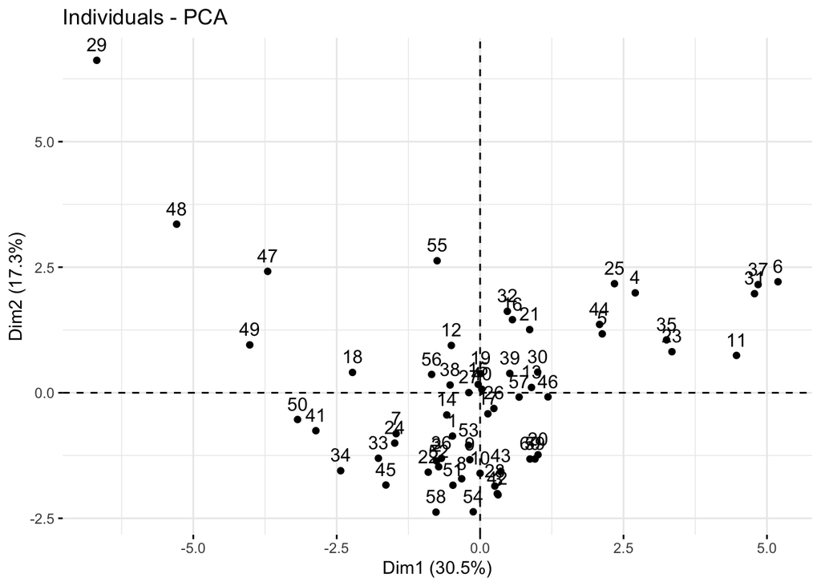

```r
fviz_pca_ind(pca)
```

• Grafique el círculo de correlación con plot(…) y con fviz_pca_var(…).

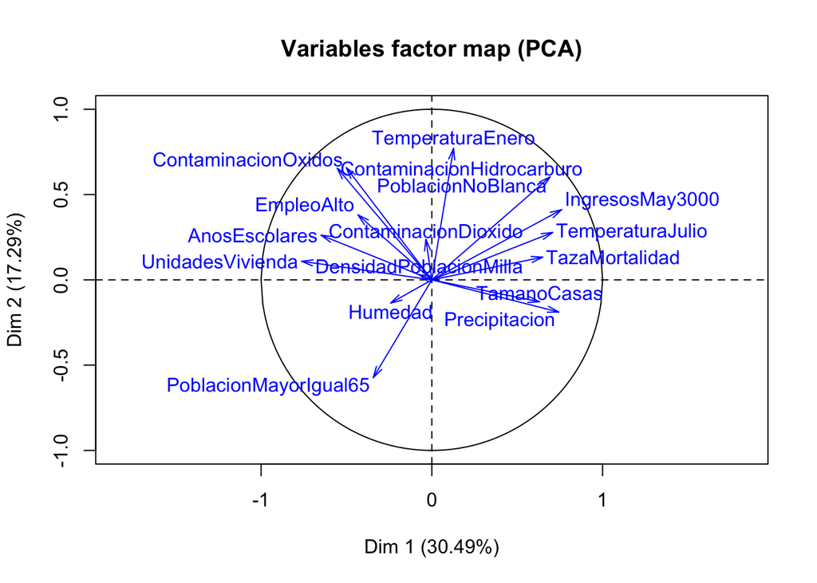

```r
plot(pca, axes=c(1, 2), choix="var", col.var="blue",new.plot=TRUE)
```

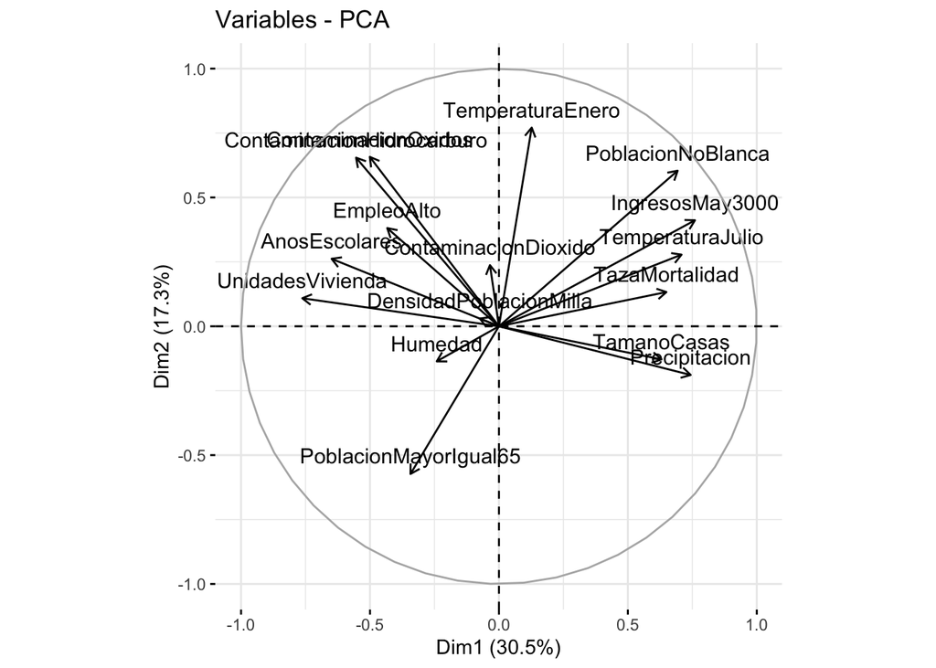

```r
fviz_pca_var(pca)
```

• Repita los ejercicios anteriores pero esta vez elimine individuos y variables mal representados (coseno cuadrado menor al 10 %). ¿Cuáles individuos y variables se eliminaron?

Existen diversas formas de seleccionar qué variables contribuyen a la explicación de un fenómeno en específico, en este primer caso, se puede sacar la media de aporte a las primeras dos dimensiones, con el fin de explicar el mayor procentaje posible.

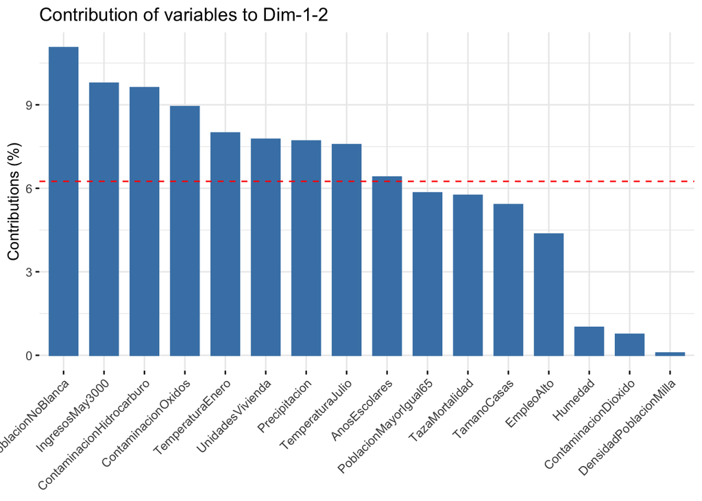

```r
fviz_pca_contrib(pca, choice = "var", axes = 1:2)
```

En este segundo caso, el que se utilizará para realizar el análisis, se determina a partir del cálculo del coseno al cuadrado de cada una de las variables, con respecto a la primera dimensión, ya que esta explica la mayor parte del fenómeno.

```r
pca$var$cos2
```

```
##                                 Dim.1        Dim.2        Dim.3
## Precipitacion             0.553056023 0.0356921507 5.320748e-06
## TemperaturaEnero          0.016159532 0.5946108811 7.415070e-02
## TemperaturaJulio          0.501367167 0.0772886802 6.506502e-02
## PoblacionMayorIgual65     0.117656332 0.3285038620 8.700336e-02
## TamanoCasas               0.397371554 0.0165048050 7.180782e-05
## AnosEscolares             0.421086434 0.0686579775 2.778888e-01
## UnidadesVivienda          0.581581116 0.0118657004 2.938628e-04
## DensidadPoblacionMilla    0.005464176 0.0008997896 4.379988e-01
## PoblacionNoBlanca         0.480379296 0.3647304231 2.252303e-04
## EmpleoAlto                0.187677227 0.1453080282 1.661875e-01
## IngresosMay3000           0.578007158 0.1693382288 1.474055e-02
## ContaminacionHidrocarburo 0.306862542 0.4282844263 1.018550e-01
## ContaminacionOxidos       0.250786307 0.4323528979 1.799322e-01
## ContaminacionDioxido      0.001215889 0.0563578759 6.084150e-01
## Humedad                   0.058163666 0.0185179602 2.412294e-02
## TazaMortalidad            0.421761197 0.0176607345 2.545196e-01
##                                  Dim.4        Dim.5
## Precipitacion             0.1432154488 0.0204230819
## TemperaturaEnero          0.1472026473 0.0083816557
## TemperaturaJulio          0.0016379681 0.1883247546
## PoblacionMayorIgual65     0.3711360934 0.0016941857
## TamanoCasas               0.4069659130 0.0694423301
## AnosEscolares             0.0274063353 0.0256523095
## UnidadesVivienda          0.0353245471 0.0474454054
## DensidadPoblacionMilla    0.0051155171 0.2148224755
## PoblacionNoBlanca         0.0162473981 0.0002063333
## EmpleoAlto                0.0001250472 0.1930648357
## IngresosMay3000           0.1152673746 0.0224687492
## ContaminacionHidrocarburo 0.0070787378 0.0614135276
## ContaminacionOxidos       0.0054932759 0.0537089550
## ContaminacionDioxido      0.0387140746 0.0125280017
## Humedad                   0.0265468798 0.3034247900
## TazaMortalidad            0.0041830851 0.0005060176
```

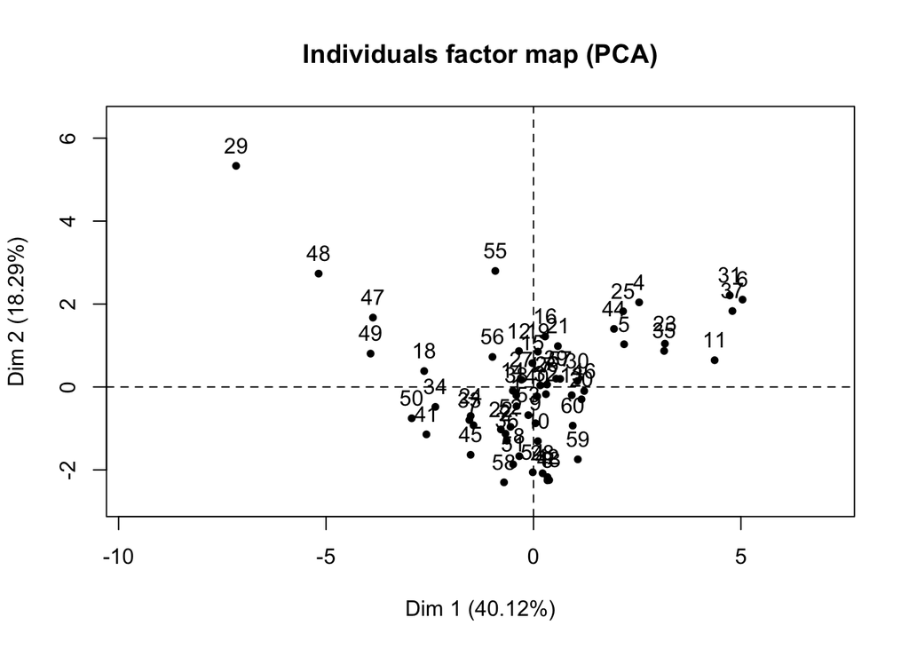

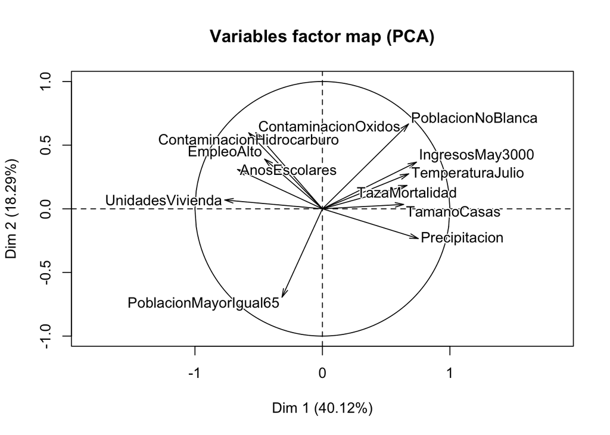

```r
contaminacion$ContaminacionDioxido <- NULL
contaminacion$TemperaturaEnero <- NULL
contaminacion$DensidadPoblacionMilla <- NULL
contaminacion$Humedad <- NULL


pca = PCA(contaminacion)
```